# Figure 6f: `WT` NeRh50 maximum amplitudes and decay rate constants for transient currents recorded in the presence of 200 mM NH₄⁺ under static pH (pH6.5), in the presence of an inward proton gradient (pH6.5 to 7.5), and in the absence of NH4+ under the same proton-gradient configuration

## The Dataset

The data used for the figure are shown in Table 1

```r
DT::datatable(dfms$dfm_6f, options=list(pageLength=5))
```

Table 1: Maximum amplitude and decay rate constant for transient currents recorded in the presence of 200 mM NH₄⁺ under static pH (pH6.5), in the presence of an inward proton gradient (pH6.5 to 7.5), and in the absence of NH4+ under the same proton-gradient configuration (figure 6f).

|  | group | day | label | amplitude | decayrate |
| --- | --- | --- | --- | --- | --- |
| 1 | pH6.5 (no gradient) | N1 | 2020-02-26-0021 | 1.074 | 68.6 |
| 2 | pH6.5 (no gradient) | N1 | 2020-02-26-0022 | 1.031 | 70.2 |
| 3 | pH6.5 (no gradient) | N1 | 2020-02-26-0023 | 1.073 | 76.1 |
| 4 | pH6.5 (no gradient) | N1 | 2020-02-26-0006 | 1.382 | 44.4 |
| 5 | pH6.5 (no gradient) | N1 | 2020-02-26-0007 | 1.279 | 52.6 |
| 6 | pH6.5 (no gradient) | N1 | 2020-02-26-0009 | 1.249 | 42.7 |
| 7 | pH6.5 (no gradient) | N2 | 2020-02-27-0003 | 2.07 | 43 |
| 8 | pH6.5&gt;7.5 gradient NH4 | N1 | 2020-02-26-0029 | 1.146 | 69 |
| 9 | pH6.5&gt;7.5 gradient NH4 | N1 | 2020-02-26-0030 | 1.203 | 65.28 |
| 10 | pH6.5&gt;7.5 gradient NH4 | N1 | 2020-02-26-0031 | 1.19 | 41.6 |

[output cut: 10 more lines]

### Downloads

- download data

## The Models

We use linear models for amplitude and decay rate as dependent variables, with group as the independent factor, checking fit in Figure 1.

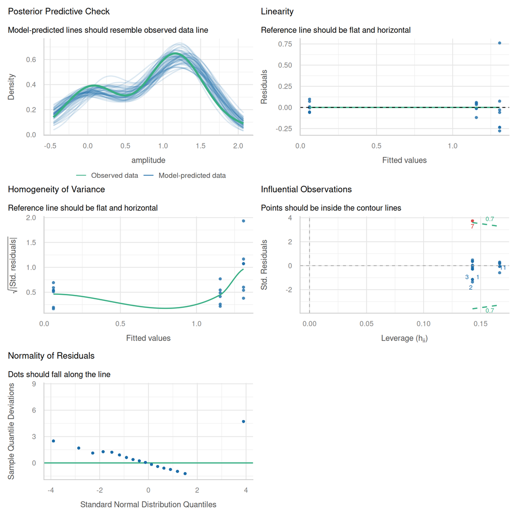

(a) `amplitude ~ group`

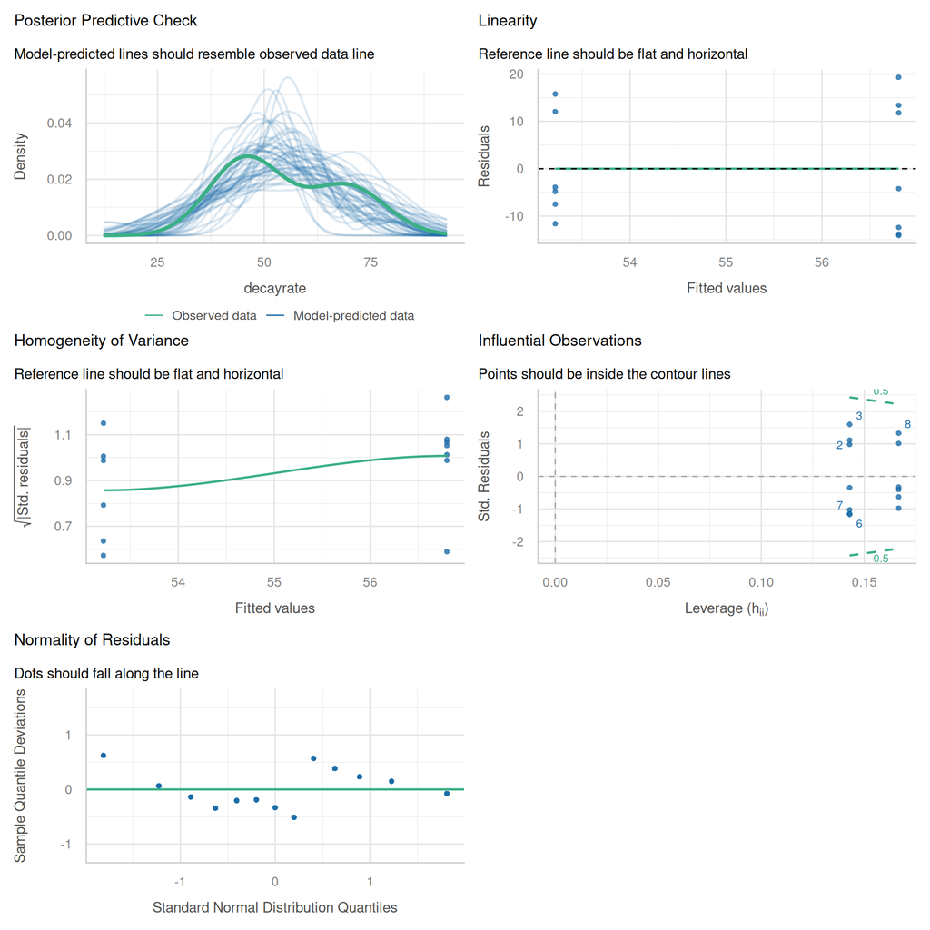

(b) `decayrate ~ group`

Figure 1: Diagnostic plots for linear model fits of `amplitude ~ group` and `decayrate ~ group`. There is some heteroscadicity in the maximum amplitude data, and there are suggestions of a slight departure from normality in the same data.

```r
# Fit the models
model6f_amp_lm <- lm(amplitude ~ group, data=dfms$dfm_6f)
model6f_k_lm <- lm(decayrate ~ group, data=dfms$dfm_6f)

# Check model fit
performance::check_model(model6f_amp_lm)
performance::check_model(model6f_k_lm)
```

As the model fit is acceptable, we estimate contrasts in Table 2.

```r
EMM <- emmeans::emmeans(model6f_amp_lm, ~ group)
confint(emmeans::contrast(EMM, "pairwise", adjust="sidak")) |>
  kableExtra::kbl(digits=3) |>
  kableExtra::kable_styling(
    bootstrap_options = c("hover", "responsive")
  )
EMM <- emmeans::emmeans(model6f_k_lm, ~ group)
confint(emmeans::contrast(EMM, "pairwise", adjust="sidak")) |>
  kableExtra::kbl(digits=3) |>
  kableExtra::kable_styling(
    bootstrap_options = c("hover", "responsive")
  )
```

Table 2: Contrasts for model fits, with Sidak adjustment. Not all contrasts include zero in the 95% confidence interval estimate.

(a) Maximum amplitude

| contrast | estimate | SE | df | lower.CL | upper.CL |
| --- | --- | --- | --- | --- | --- |
| pH6.5 (no gradient) - pH6.5>7.5 gradient NH4 | 0.153 | 0.122 | 17 | -0.171 | 0.477 |
| pH6.5 (no gradient) - pH6.5>7.5 gradient, no NH4 | 1.248 | 0.118 | 17 | 0.937 | 1.559 |
| pH6.5>7.5 gradient NH4 - pH6.5>7.5 gradient, no NH4 | 1.095 | 0.122 | 17 | 0.771 | 1.419 |

(b) Decay rate

| contrast | estimate | SE | df | lower.CL | upper.CL |
| --- | --- | --- | --- | --- | --- |
| pH6.5 (no gradient) - pH6.5>7.5 gradient NH4 | 3.58 | 7.266 | 11 | -12.411 | 19.571 |

For the maximum amplitude data we find that all contrasts with the pH6.5 to pH7.5 gradient with no NH4+ exclude zero from the 95% CI, but the contrast between pH6.5 and pH6.5 to pH7.5 with NH4+ indicates no difference between groups. There is also no support for a difference in decay rate constant between pH6.5 and pH6.5 to pH7.5 with NH4+.

## The Figures

We plot the data, indicating P-values for the contrasts in Figure 2.

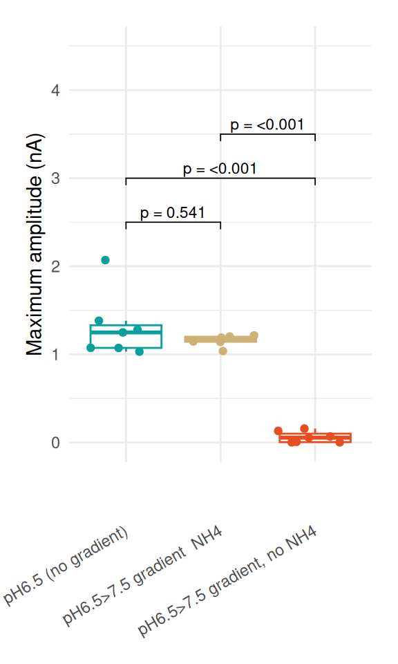

(a) Figure 6f, maximum amplitude

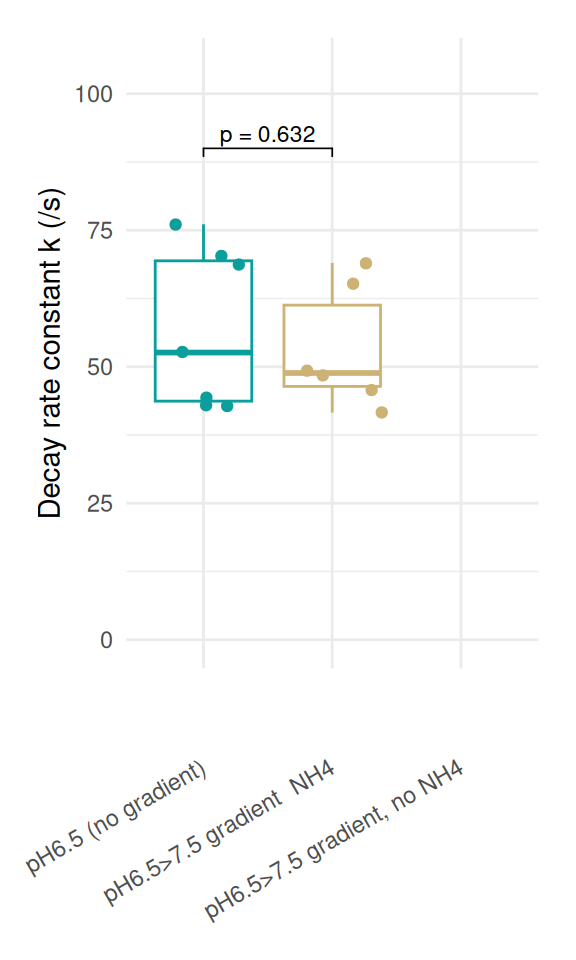

(b) Figure 6f, decay rate

```r
# Get p-values, accounting for heteroscedasticity and multiple testing
# Also generate group1 and group2 columns
EMM_amp <- as.data.frame(pairs(emmeans::emmeans(model6f_amp_lm, ~ group),
                               adjust="sidak")) |>
  tidyr::separate(contrast, into=c("group1", "group2"), sep=" - ") |>
  dplyr::mutate(y.position=2.5) |>
  rstatix::add_significance()

EMM_k <- as.data.frame(pairs(emmeans::emmeans(model6f_k_lm, ~ group),
                               adjust="sidak")) |>
  tidyr::separate(contrast, into=c("group1", "group2"), sep=" - ") |>
  dplyr::mutate(y.position=90) |>
  rstatix::add_significance()

p6f_amp <- ggplot2::ggplot(dfms$dfm_6f,
                           ggplot2::aes(x=group, y=amplitude, color=group)) +
  ggplot2::geom_boxplot(outlier.shape = NA) +
  ggplot2::geom_jitter() +
  ggplot2::labs(y="Maximum amplitude (nA)", x="") +
  ggplot2::ylim(0, 4.5) +
  ggplot2::theme_minimal() +
  ggpubr::stat_pvalue_manual(EMM_amp,
                             label="p = {scales::pvalue(p.value)}",
                             size=3, step.increase=0.2)+
  ggplot2::theme(legend.position = "none",
                 axis.text.x = ggplot2::element_text(angle = 30, vjust = 0.5, hjust=1),
                 plot.margin=ggplot2::unit(c(0.5,0.5,1,0.5), 'cm'))

p6f_k <- ggplot2::ggplot(dfms$dfm_6f,
                         ggplot2::aes(x=group, y=decayrate, color=group)) +
  ggplot2::geom_boxplot(outlier.shape = NA) +
  ggplot2::geom_jitter() +
  ggplot2::labs(y="Decay rate constant k (/s)", x="") +
  ggplot2::ylim(0, 105) +
  ggplot2::theme_minimal() +
  ggpubr::stat_pvalue_manual(EMM_k,
                             label="p = {scales::pvalue(p.value)}",
                             size=3, step.increase=0.15)+
  ggplot2::theme(legend.position = "none",
                 axis.text.x = ggplot2::element_text(angle = 30, vjust = 0.5, hjust=1),
                 plot.margin=ggplot2::unit(c(0.5,0.5,1,0.5), 'cm'))

p6f_amp
p6f_k

# Write figures to file (commented out for webpage)
#ggplot2::ggsave("assets/images/fig6f_WT_maximum_amplitude.pdf", p6f_amp)
#ggplot2::ggsave("assets/images/fig6f_WT_maximum_amplitude.png", p6f_amp)
#ggplot2::ggsave("assets/images/fig6f_WT_decay_rate_constant.png", p6f_k)
#ggplot2::ggsave("assets/images/fig6f_WT_decay_rate_constant.pdf", p6f_k)
```

### Downloads

- Download maximum amplitude figure as .pdf
- Download maximum amplitude figure as .png
- Download decay rate constant figure as .pdf
- Download decay rate constant figure as .png